```r
library("RColorBrewer")
```

## Project 1

This R Markdown-file contains the code for **Project 1** in the course **TMA4265** Stochastic Modelling. The group consists of

- *Ola Runeson Rasmussen*
- *Sigurd Kampevold Johanson*
- *Hanne Blomdal Laupstad*

Do note that the estimated probabilities, confidence intervals, realizations, and other computations in the notebook may vary slightly from the numbers in the report, as we have not set the seed for the randomizations. Moreover, the outputs in this file will not be delivered as we deliver the raw .Rmd-file rather than an .html-file with the output.

### Problem 1

**c)**

Simulate the Markov chain for 20 years (7300 steps):

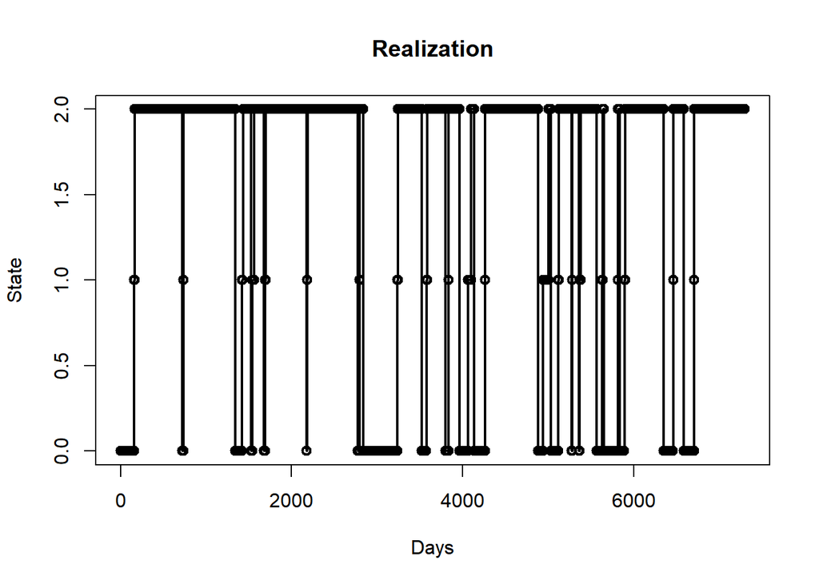

```r
# Initializing the transition probability matrix
P <- matrix(c(0.99, 0.01, 0, 0, 0.9, 0.1, 0.005, 0, 0.995), nrow = 3, byrow = TRUE)

# The number of steps
N <- 7300

# The vector to hold the states
x <- vector("numeric", length = N + 1)

# Initial state
x[1] <- 0

# Simulating the chain repeatedly
for(n in 1:N){

  # Drawing the next state from the distribution
  x[n + 1] = sample.int(3, size = 1, replace = TRUE, prob = P[x[n] + 1, ]) - 1
}

# Plotting the results
plot(0:N, x, type = "o", lwd = 2, main = "Realization", xlab = "Days", ylab = "State")
```

For each run of this code, use the last 10 years (of the 20 years) to get an estimate of each of the quantities in b):

```r
# Extract the last 10 years of the run above
x_new <- tail(x, 3650)

# Compute the number of entries to each state
tab <- table(x_new)

# Compute the fraction of time spent in each state, i.e., the limiting distribution
limiting <- c(tab[1] / 3650, tab[2] / 3650, tab[3] / 3650)
limiting
```

```
##         0         1         2
## 0.2536986 0.0430137 0.7032877
```

Run the code 30 times and compute an approximate 95% confidence interval (CI) for each of the quantities in **b)** (using the 30 independent estimates).

```r
# Number of iterations
n_iter <- 30

# Vectors to hold the values from each run
values_0 <- vector("numeric", length = n_iter)
values_1 <- vector("numeric", length = n_iter)
values_2 <- vector("numeric", length = n_iter)

# Iterate through the n_iter runs
for (iter in 1:n_iter){
  # Vector to hold the simulation of the chain
  x <- vector("numeric", length = N + 1)

  # Initial state
  x[1] <- 0

  # Simulate the chain as in b)
  for(n in 1:N){
    x[n + 1] = sample.int(3, size = 1, replace = TRUE, prob = P[x[n] + 1, ]) - 1
  }

  # Compute the approximation of the limiting distribution for this run
  tab <- table(x)
  limiting <- c(tab[1] / N, tab[2] / N, tab[3] / N)

  # Append the number of days per year spent in each state to the respective vector
  values_0[iter] = limiting[1] * 365
  values_1[iter] = limiting[2] * 365
  values_2[iter] = limiting[3] * 365

}

# Compute the CIs as percentiles
print("95% confidence interval for number of days in state 0:")
```

```
## [1] "95% confidence interval for number of days in state 0:"
```

```r
unname(quantile(values_0, c(.025, .975)))
```

```
## [1]  75.57625 155.23375
```

```r
print("95% confidence interval for number of days in state 1:")
```

```
## [1] "95% confidence interval for number of days in state 1:"
```

```r
unname(quantile(values_1, c(.025, .975)))
```

```
## [1]  7.66750 16.89125
```

```r
print("95% confidence interval for number of days1 in state 2:")
```

```
## [1] "95% confidence interval for number of days1 in state 2:"
```

```r
unname(quantile(values_2, c(.025, .975)))
```

```
## [1] 194.4800 279.1437
```

**e)**

Simulate $Y_n$ for $n = 300$ trials.

```r
# Initialize number of trials and vectors
N <- 300
s <- vector("numeric", length = N + 1)
i <- vector("numeric", length = N + 1)
r <- vector("numeric", length = N + 1)

# Initial "states"
s[1] <- 950
i[1] <- 50
r[1] <- 0

for (n in 1:N) {
  # Draw the number of new people to each state
  s_new <- rbinom(1, r[n], 0.005)
  i_new <- rbinom(1, s[n], 0.5 * i[n] / 1000)
  r_new <- rbinom(1, i[n], 0.1)

  # Compute the number of people in each state at the next time step
  s[n + 1] = s[n] + s_new - i_new
  i[n + 1] = i[n] + i_new - r_new
  r[n + 1] = r[n] + r_new - s_new
}
```

Plot the realization.

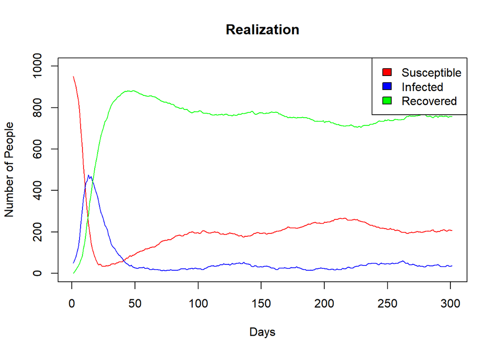

```r
# Plot the realization
steps <- seq(1, 301, 1)

plot(steps, s, type = "l", col = "red", main = "Realization", xlab = "Days", ylab = "Number of People", ylim = c(0, 1000))
lines(steps, i, type = "l", col = "blue")
lines(steps, r, type = "l", col = "green")
legend("topright", legend = c("Susceptible", "Infected", "Recovered"), fill = c("red", "blue", "green"))
```

**f)**

Estimate the expected maximum number of infected individuals during the simulated time steps and the expected time at which the number of infected individuals first takes it highest value.

```r
# Number of iterations
n_iter <- 1000

# Vectors to hold values for each iteration
largest_i = vector("numeric", length = n_iter)
largest_step_i = vector("numeric", length = n_iter)

for (iter in 1:n_iter) {
  # Vectors for the simulation
  N <- 300
  s <- vector("numeric", length = N + 1)
  i <- vector("numeric", length = N + 1)
  r <- vector("numeric", length = N + 1)

  # Initial state
  s[1] <- 950
  i[1] <- 50
  r[1] <- 0

  # Variables to store values of interest
  max <- 0
  max_index <- 0

  # Simulate
  for (n in 1:N) {
    s_new <- rbinom(1, r[n], 0.005)
    i_new <- rbinom(1, s[n], 0.5 * i[n] / 1000)
    r_new <- rbinom(1, i[n], 0.1)

    s[n + 1] = s[n] + s_new - i_new
    i[n + 1] = i[n] + i_new - r_new
    r[n + 1] = r[n] + r_new - s_new

    # Update the value of interest
    if (i[n + 1] > max) {
      max <- i[n + 1]
      max_index <- n + 1
    }
  }

  # Store values
  largest_i[iter] = max
  largest_step_i[iter] = max_index
}

c("Expected maximum number of infected:"= mean(largest_i),
  "Expected time step to reach maximum number:" = mean(largest_step_i))
```

```
##        Expected maximum number of infected:
##                                     523.039
## Expected time step to reach maximum number:
##                                      12.882
```

```r
c("95% confidence interval on maximum number of infected individuals:")
```

```
## [1] "95% confidence interval on maximum number of infected individuals:"
```

```r
unname(quantile(largest_i, c(.025, .975)))
```

```
## [1] 483 562
```

```r
c("95% confidence interval on time step to reach maximum number:")
```

```
## [1] "95% confidence interval on time step to reach maximum number:"
```

```r
unname(quantile(largest_step_i, c(.025, .975)))
```

```
## [1] 11 14
```

**g)**

The only elements in the below code that are different from the above simulations are the initial states and the initial population. Thus, the following code chunks are not commented, as we see it unnecessary.

Case 1 - 100 vaccinated individuals:

```r
n_iter <- 1000
n_vacc <- 100

largest_i = vector("numeric", length = n_iter)
largest_step_i = vector("numeric", length = n_iter)

for (iter in 1:n_iter) {
  N <- 300
  s <- vector("numeric", length = N + 1)
  i_case1 <- vector("numeric", length = N + 1)
  r <- vector("numeric", length = N + 1)

  s[1] <- 950 - n_vacc
  i_case1[1] <- 50
  r[1] <- 0

  max <- 0
  max_index <- 0

  for (n in 1:N) {
    s_new <- rbinom(1, r[n], 0.005)
    i_new <- rbinom(1, s[n], 0.5 * i[n] / 1000)
    r_new <- rbinom(1, i_case1[n], 0.1)

    s[n + 1] = s[n] + s_new - i_new
    i_case1[n + 1] = i_case1[n] + i_new - r_new
    r[n + 1] = r[n] + r_new - s_new

    if (i_case1[n + 1] > max) {
      max <- i_case1[n + 1]
      max_index <- n + 1
    }
  }

  largest_i[iter] = max
  largest_step_i[iter] = max_index
}

c("Expected maximum number of infected:"= mean(largest_i),
  "Expected time step to reach maximum number:" = mean(largest_step_i))
```

```
##        Expected maximum number of infected:
##                                     477.234
## Expected time step to reach maximum number:
##                                      12.667
```

Case 2 - 600 vaccinated individuals:

```r
n_iter <- 1000
n_vacc <- 600

largest_i = vector("numeric", length = n_iter)
largest_step_i = vector("numeric", length = n_iter)

for (iter in 1:n_iter) {
  N <- 300
  s <- vector("numeric", length = N + 1)
  i_case2 <- vector("numeric", length = N + 1)
  r <- vector("numeric", length = N + 1)

  s[1] <- 950 - n_vacc
  i_case2[1] <- 50
  r[1] <- 0

  max <- 0
  max_index <- 0

  for (n in 1:N) {
    s_new <- rbinom(1, r[n], 0.005)
    i_new <- rbinom(1, s[n], 0.5 * i[n] / 1000)
    r_new <- rbinom(1, i_case2[n], 0.1)

    s[n + 1] = s[n] + s_new - i_new
    i_case2[n + 1] = i_case2[n] + i_new - r_new
    r[n + 1] = r[n] + r_new - s_new

    if (i_case2[n + 1] > max) {
      max <- i_case2[n + 1]
      max_index <- n + 1
    }
  }

  largest_i[iter] = max
  largest_step_i[iter] = max_index
}

c("Expected maximum number of infected:"= mean(largest_i),
  "Expected time step to reach maximum number:" = mean(largest_step_i))
```

```
##        Expected maximum number of infected:
##                                     206.966
## Expected time step to reach maximum number:
##                                      12.494
```

Case 3 - 800 vaccinated individuals:

```r
n_iter <- 1000
n_vacc <- 800

largest_i = vector("numeric", length = n_iter)
largest_step_i = vector("numeric", length = n_iter)

for (iter in 1:n_iter) {
  N <- 300
  s <- vector("numeric", length = N + 1)
  i_case3 <- vector("numeric", length = N + 1)
  r <- vector("numeric", length = N + 1)

  s[1] <- 950 - n_vacc
  i_case3[1] <- 50
  r[1] <- 0

  max <- 0
  max_index <- 0

  for (n in 1:N) {
    s_new <- rbinom(1, r[n], 0.005)
    i_new <- rbinom(1, s[n], 0.5 * i[n] / 1000)
    r_new <- rbinom(1, i_case3[n], 0.1)

    s[n + 1] = s[n] + s_new - i_new
    i_case3[n + 1] = i_case3[n] + i_new - r_new
    r[n + 1] = r[n] + r_new - s_new

    if (i_case3[n + 1] > max) {
      max <- i_case3[n + 1]
      max_index <- n + 1
    }
  }

  largest_i[iter] = max
  largest_step_i[iter] = max_index
}

c("Expected maximum number of infected:"= mean(largest_i),
  "Expected time step to reach maximum number:" = mean(largest_step_i))
```

```
##        Expected maximum number of infected:
##                                      99.001
## Expected time step to reach maximum number:
##                                      12.089
```

Visualization of differences for evolution of $I_n$:

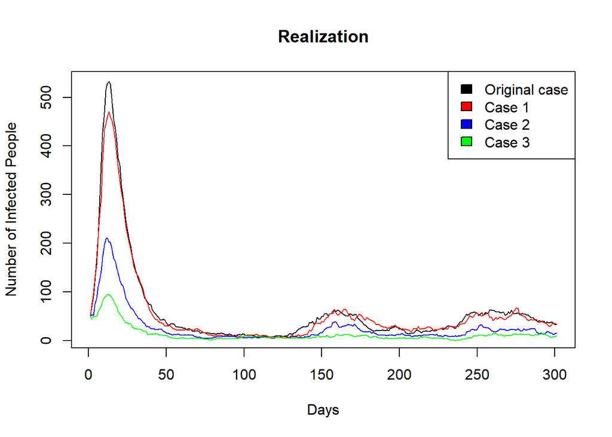

```r
steps <- seq(1, 301, 1)

plot(steps, i, type = "l", col = "black", main = "Realization", xlab = "Days", ylab = "Number of Infected People")
lines(steps, i_case1, type = "l", col = "red")
lines(steps, i_case2, type = "l", col = "blue")
lines(steps, i_case3, type = "l", col = "green")
legend("topright", legend = c("Original case", "Case 1", "Case 2", "Case 3"), fill = c("black", "red", "blue", "green"))
```

### Problem 2

**a)**

Write code to verify the calculation by simulating 1000 realizations of the Poisson process.

```r
# Defining parameters to be used
t <- 59
lambda <- 1.5
N <- 1000
x <- vector("numeric", N + 1)

# Iterating through the simulations
for (i in 1:N){
  # Draws the number of events to occur before t = 59
  n_events <- rpois(1, lambda * t)

  # Append 1 to the x-vector if more than 100 events occur, else, append 0
  if (n_events > 100){
    x[i] = 1
  } else {
    x[i] = 0
  }
}

# Compute the mean of the x-vector representing the desired probability
mean(x)
```

```
## [1] 0.0979021
```

Make a figure that shows 10 realizations of $X(t), 0 \leq t \leq 59$, plotted in the same figure.

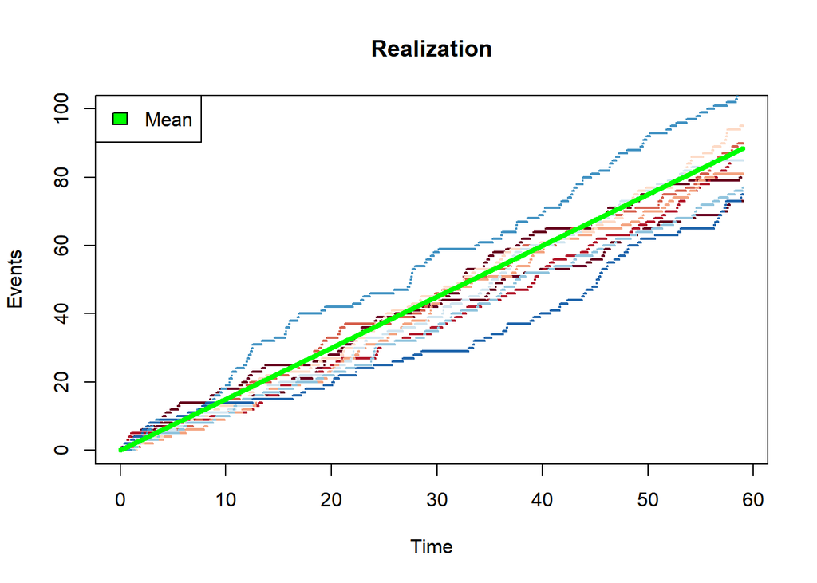

```r
# Defining parameters
cols <- brewer.pal(n = 10, name = 'RdBu')
t <- 59
lambda <- 1.5
N <- 9

# First simulation
# Draw the number of events from a Poission distribution
n_events <- rpois(1, lambda * t)

# Draw and sort the placement of events from a uniform distribution
t_values <- runif(n_events, 0, t)
t_values = c(0, sort(t_values), t)

# Values for plotting
x_values = c(0:n_events, n_events)

# Plotting
plot(NULL, NULL, xlim = c(0, t), ylim = c(0, 100), xlab = "Time", ylab = "Events", main = "Realization", lwd = 2)

for (i in 1:(length(x_values) - 1)){
  lines(t_values[i:(i + 1)], rep(x_values[i], 2), lwd = 2, col = cols[1])
}

# Repeating for the last 9 simulations, and appending the simulations to the plot
for (n in 1:N) {
  n_events <- rpois(1, lambda * t)

  t_values <- runif(n_events, 0, t)

  t_values = c(0, sort(t_values), t)

  x_values = c(0:n_events, n_events)

  for (i in 1:(length(x_values) - 1)){

    lines(t_values[i:(i + 1)], rep(x_values[i], 2), lwd = 2, col = cols[n])

  }
}

# Appending the mean to the visualization
lines(c(0, t), c(0, lambda * t), col = "green", lwd = 4)

legend("topleft", legend = c("Mean"), fill = c("green"))
```

**b)** Write code that uses 1000 simulations to estimate the probability that the total claim exceeds 8 mill. kr. at March 1.

```r
# Initializing parameters and variables
N <- 1000
gamma <- 10
lambda <- 1.5
t <- 59
values <- vector("numeric", N)

# Iterating through the simulations
for (n in 1:N) {
  # Drawing the number of events from a Poisson distribution
  n_events <- rpois(1, lambda * t)

  # Vector to hold the claims
  z_vector <- vector("numeric", n_events)

  # Iterating through the events
  for (i in 1:n_events){
    # Drawing and appending the claim from an exponential distribution
    claim <- rexp(1, gamma)
    z_vector[i] = claim
  }

  # Append 1 if the sum of the claims exceed 8 mill. kr., else, append 0
  if (sum(z_vector) > 8) {
    values[n] = 1
  } else {
    values[n] = 0
  }
}

# Compute the mean of the values vector to estimate the probability
mean(values)
```

```
## [1] 0.728
```

Make a figure that shows 10 realizations of $Z(t), 0 \leq t \leq 59$, plotted in the same figure.

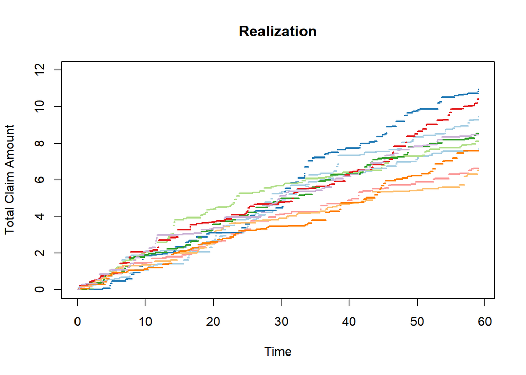

```r
# Initializing
cols <- brewer.pal(n = 10, name = 'Paired')
gamma <- 10
lambda <- 1.5
t <- 59
N <- 9

# Simulating the first realization
# Drawing the number of events from a Poisson distribution
n_events <- rpois(1, lambda * t)

# Drawing and sorting the placement of events from a uniform distribution
t_values <- runif(n_events, 0, t)
t_values = c(0, sort(t_values), t)

# Values for plotting
x_values = c(0:n_events, n_events)

# Initializing z-vector to hold claims
z_vector <- vector("numeric", n_events)

# Iterating through the events, i.e., claims
for (i in 1:n_events){
  # Drawing and appending size of claim from an exponential distribution
  claim <- rexp(1, gamma)
  z_vector[i] = claim
}

# Initializing a cumulative vector from the z-vector
z_cum <- c(0, cumsum(z_vector))

# Plotting the realization
plot(NULL, NULL, xlim = c(0, t), ylim = c(0, 12), xlab = "Time", ylab = "Total Claim Amount", main = "Realization", lwd = 2)

for (i in 1:(length(x_values) - 1)){
  lines(t_values[i:(i + 1)], rep(z_cum[i], 2), lwd = 2, col = cols[1])
}

# Simulating the 9 last realizations and appending them to the visualization
for (n in 1:N) {
  n_events <- rpois(1, lambda * t)

  t_values <- runif(n_events, 0, t)

  t_values = c(0, sort(t_values), t)

  x_values = c(0:n_events, n_events)

  z_vector <- vector("numeric", n_events)

  for (i in 1:n_events){
    claim <- rexp(1, gamma)
    z_vector[i] = claim
  }

  z_cum <- c(0, cumsum(z_vector))

  for (i in 1:(length(x_values) - 1)){
    lines(t_values[i:(i + 1)], rep(z_cum[i], 2), lwd = 2, col = cols[n])
  }
}
```